# **Indicador de Efetividade**

## Relatório de impacto do fomento do CNPq no número de publicações de artigos segundo o Web of Science.

## **• Metodologia**

> Os dados para a confecção dos gráficos foram coletados a partir da plataforma “Web of Science”, utilizando um filtro especifico para “Agencias Financiadoras” dentro do ambiente “Pesquisas avanças” disponível no próprio site. A extração de dados foi feita durante a primeira semana de Fevereiro de 2019, e foram considerados apenas os dados de 2008 até 2019, que foram extraídos diretamente do site a partir do download de arquivos CSV contendo de duas a três colunas de dados. Algumas modificações matemáticas, tais como somas de informações duplicadas e arrendamentos foram feitos para facilitar a analise, além disso, modificações estruturais nos arquivos CSV, para corrigir má formatações e facilitar a leitura, também foram feitas.

## **• Resultados**

> **1. Impacto do fomento do CNPq no número de artigos indexados na Web of Science por ano de publicação.**

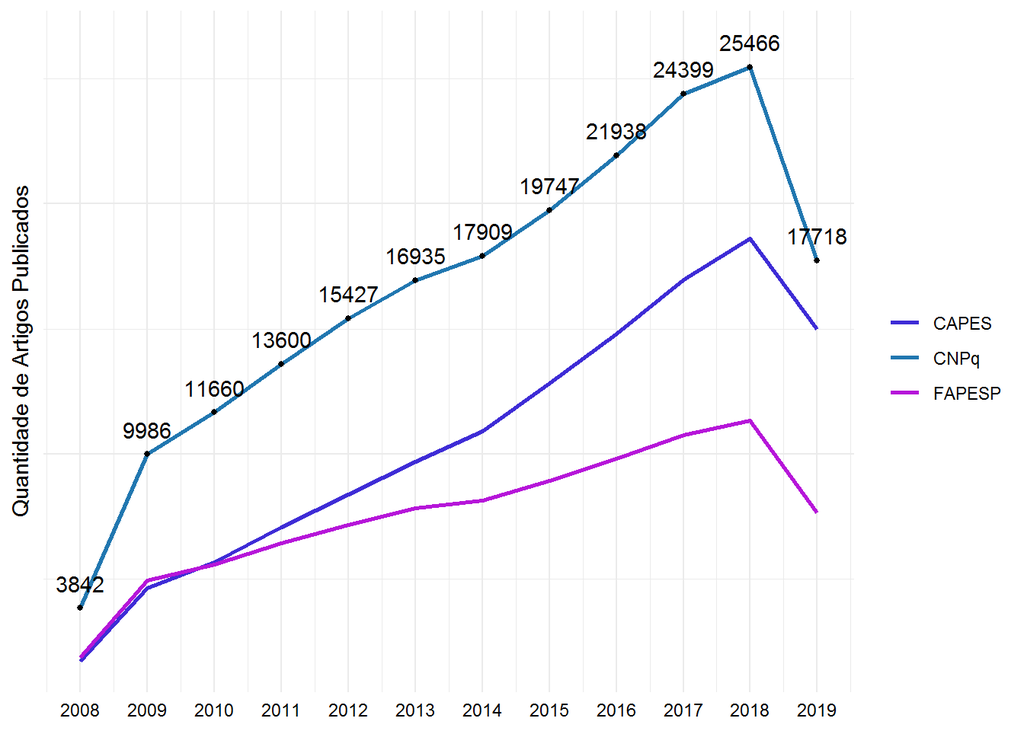

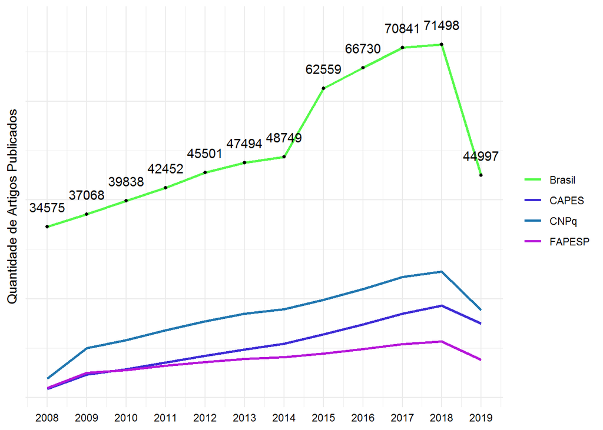

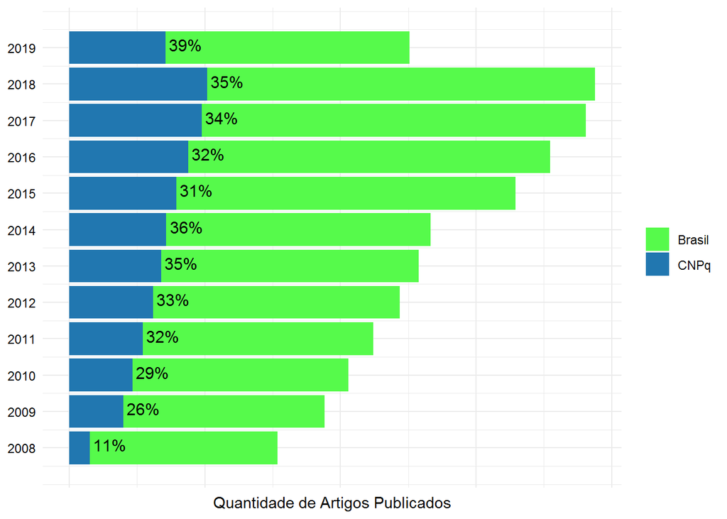

Notas:

1 - A contagem dos dados considera o número de artigos que contenham autores brasileiros;

2 - A contagem não considera cofinaciamento, podendo haver dupla contagem;

> **2. Acumulado da nacionalidade e filiação institucional dos artigos fomentados pelo CNPq.**

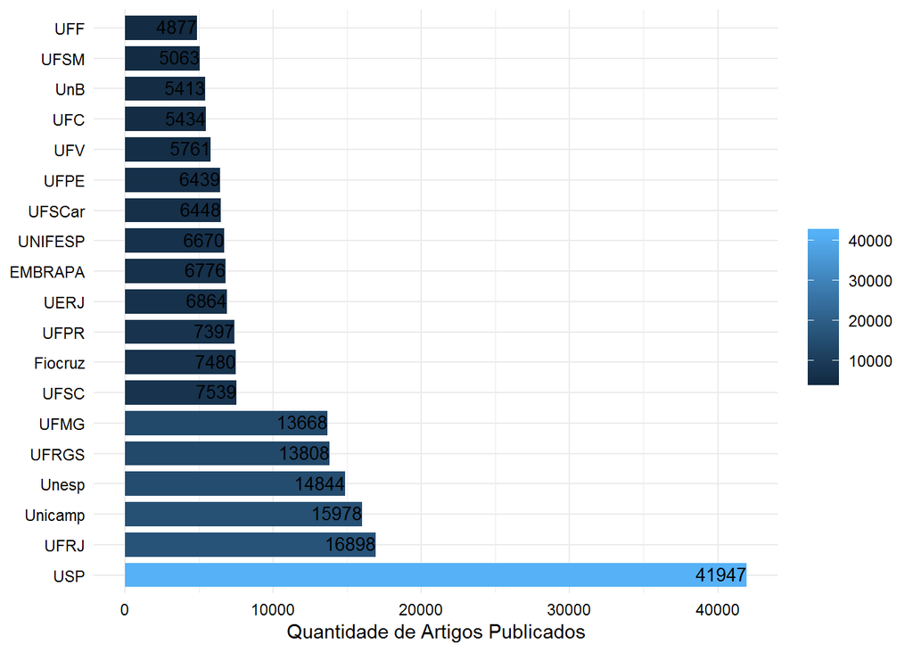

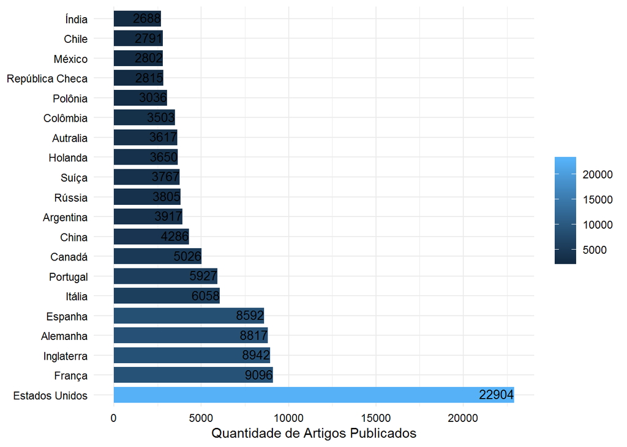

Nota:

1 - A contagem não considera mais de uma filiação, podendo haver dupla contagem.